# MedidasDispersion

Gabriel

2022-04-01

- Valores minimo y maximo `range(x)`
- Rango `diff(range(x))`
- Rango Intercuartilico `IQR(x, type = ...)`
- Varianza muestral `var(x)`
- Desviacion tipica muestral `sd(x)`
- Varianza `var(x)*(length(x)-1)/length(x)`
- Desviacion tipica `sd(x)*(length(x)-1)/length(x)`

```r
set.seed(2022)
dados = sample(1:6, 20, replace = TRUE)
dados
```

```
##  [1] 4 3 6 3 4 6 6 4 3 1 6 5 2 6 5 1 3 1 2 2
```

```r
set.seed(NULL)
```

```r
range(dados)
```

```
## [1] 1 6
```

```r
diff(range(dados))
```

```
## [1] 5
```

```r
IQR(dados)
```

```
## [1] 3.25
```

```r
var(dados)
```

```
## [1] 3.292105
```

```r
sd(dados)
```

```
## [1] 1.814416
```

```r
var(dados)*(length(dados)-1)/length(dados)
```

```
## [1] 3.1275
```

```r
sd(dados)*(length(dados)-1)/length(dados)
```

```
## [1] 1.723695
```

### Funcion summary()

Devuelve valores estadisticos varios del vector a tratar, en un dataframe, muestra los estadisticos para cada variable

```r
summary(dados)
```

```
##    Min. 1st Qu.  Median    Mean 3rd Qu.    Max.
##    1.00    2.00    3.50    3.65    5.25    6.00
```

### Funcion by()

Aplica una funcion a algunas columnas del df, segun niveles de un factor

```r
by(iris[,c(1,3)], iris$Species, FUN = summary)
```

```
## iris$Species: setosa
##   Sepal.Length    Petal.Length
##  Min.   :4.300   Min.   :1.000
##  1st Qu.:4.800   1st Qu.:1.400
##  Median :5.000   Median :1.500
##  Mean   :5.006   Mean   :1.462
##  3rd Qu.:5.200   3rd Qu.:1.575
##  Max.   :5.800   Max.   :1.900
## ------------------------------------------------------------
## iris$Species: versicolor
##   Sepal.Length    Petal.Length
##  Min.   :4.900   Min.   :3.00
##  1st Qu.:5.600   1st Qu.:4.00
##  Median :5.900   Median :4.35
##  Mean   :5.936   Mean   :4.26
##  3rd Qu.:6.300   3rd Qu.:4.60
##  Max.   :7.000   Max.   :5.10
## ------------------------------------------------------------
## iris$Species: virginica
##   Sepal.Length    Petal.Length
##  Min.   :4.900   Min.   :4.500
##  1st Qu.:6.225   1st Qu.:5.100
##  Median :6.500   Median :5.550
##  Mean   :6.588   Mean   :5.552
##  3rd Qu.:6.900   3rd Qu.:5.875
##  Max.   :7.900   Max.   :6.900
```

### Funcion aggregate()

Se usa muy similar a la funcion by, no obstante los resultados son distintos

```r
aggregate(cbind(Sepal.Length, Petal.Length)~Species, data = iris, FUN = summary) #Column bind, dame dos columnas y agrupa por
```

```
##      Species Sepal.Length.Min. Sepal.Length.1st Qu. Sepal.Length.Median
## 1     setosa             4.300                4.800               5.000
## 2 versicolor             4.900                5.600               5.900
## 3  virginica             4.900                6.225               6.500
##   Sepal.Length.Mean Sepal.Length.3rd Qu. Sepal.Length.Max. Petal.Length.Min.
## 1             5.006                5.200             5.800             1.000
## 2             5.936                6.300             7.000             3.000
## 3             6.588                6.900             7.900             4.500
##   Petal.Length.1st Qu. Petal.Length.Median Petal.Length.Mean
## 1                1.400               1.500             1.462
## 2                4.000               4.350             4.260
## 3                5.100               5.550             5.552
##   Petal.Length.3rd Qu. Petal.Length.Max.
## 1                1.575             1.900
## 2                4.600             5.100
## 3                5.875             6.900
```

### Algo que siempre considerar

Descartar los NA, esto no permite usar ninguna de las funciones anteriores, considerar siempre `na.rm = TRUE`

## Boxplot

Remarca 5 valores estadisticos, mediana, rango intercuartilico, maximos y minimos, y outliers si hay maximos mayores a 1.5 del rango intercuartilico, marcan el minmo y el maximo a no ser que haya valores muy alejados, estos quedan en los outliers

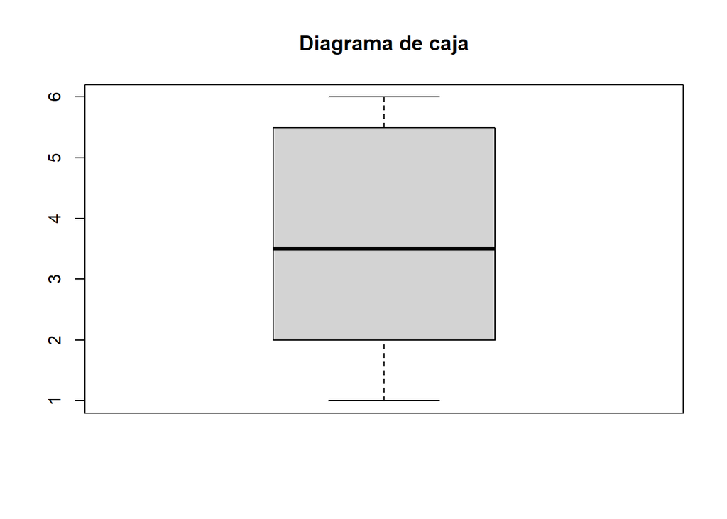

```r
boxplot(dados, main = "Diagrama de caja")
```

### Boxplot para todo un dataframe

No es lo recomendable, dado que no todas las variab2les entran dentro del mismo rango de valores

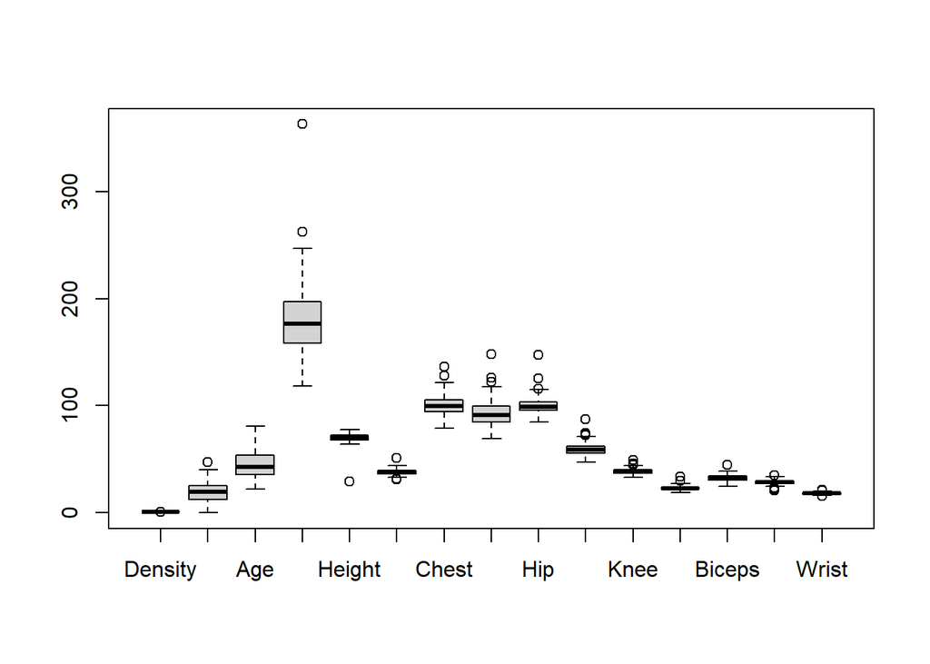

```r
body = read.table("../data/bodyfat.txt", header = TRUE)
boxplot(body)
```

Por eso se recurre a usar las variables que manejen rangos similares para poder usar el boxplot

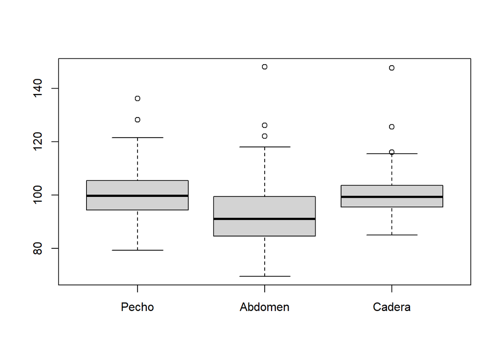

```r
boxplot(body[,c(7,8,9)], names = c("Pecho", "Abdomen", "Cadera"))
```

El objetivo es para comparar variables visualmente, cuando tienen relacion en si, una variable y un factor, agrupando por sus niveles la variable, esto me da distintos boxplots, comparables entre si, es una manera mucho mas facil de comparar

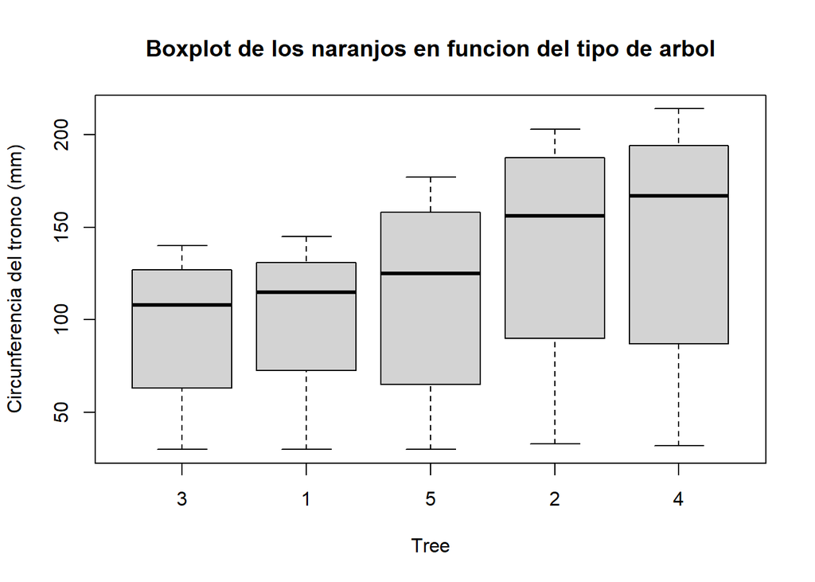

```r
boxplot(circumference~Tree, data = Orange, ylab = "Circunferencia del tronco (mm)",
        main = "Boxplot de los naranjos en funcion del tipo de arbol")
```

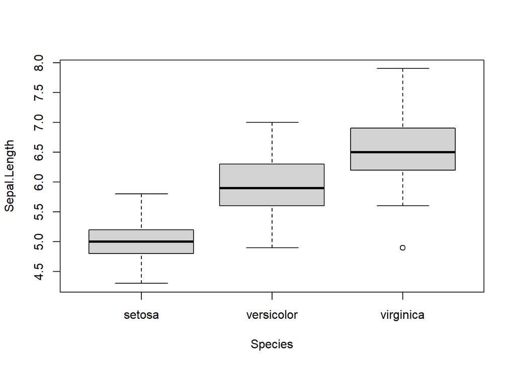

```r
boxplot(Sepal.Length~Species, data = iris)
```

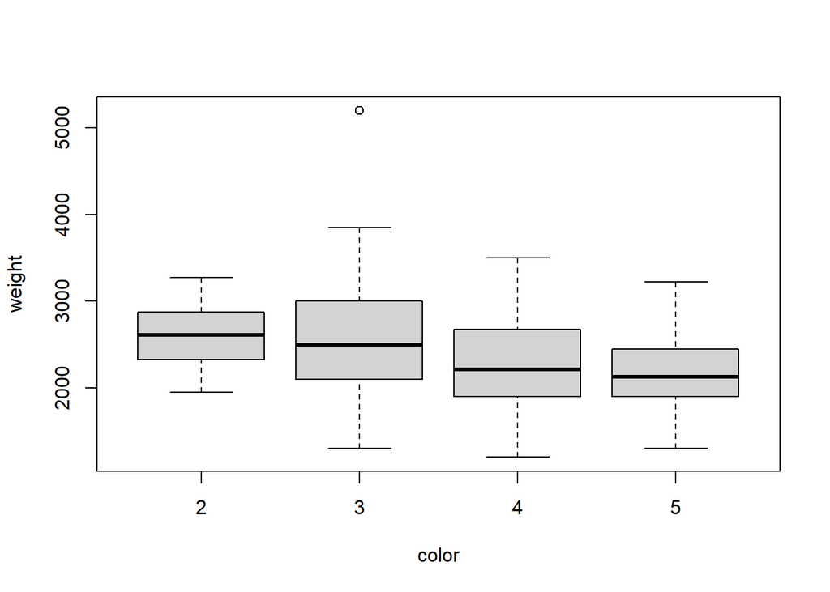

```r
data = read.table("../data/datacrab.txt", header = TRUE)
boxplot(weight~color, data = data)
```

### Parametro notch

Hace una muesca en las mediana de las cajas, si las medianas no se solapan, se concluye que las poblaciones son diferentes con alto grado de confianza

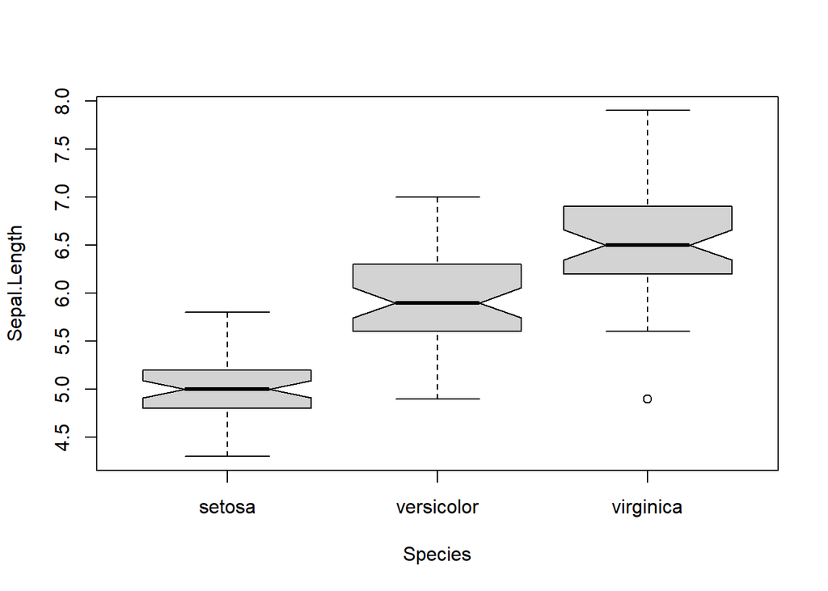

```r
boxplot(Sepal.Length~Species, data = iris, notch = TRUE)
```

Podemos calcular mas medidas y agregarlas mediante points al grafico

### Estructuras de los boxplots

Generan una estrucutra interna muy rica de informacion

- stats, los valores que utilizan, niveles, cuartiles
- out, nos devuelve los outliers que tiene la box

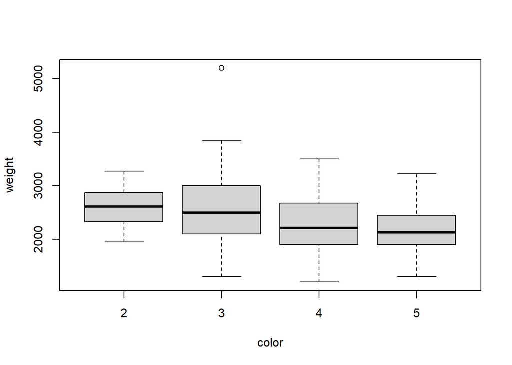

```
## List of 6
##  $ stats: num [1:5, 1:4] 1950 2325 2612 2875 3275 ...
##  $ n    : num [1:4] 12 95 44 22
##  $ conf : num [1:2, 1:4] 2362 2863 2354 2646 2028 ...
##  $ out  : num 5200
##  $ group: num 2
##  $ names: chr [1:4] "2" "3" "4" "5"
```

```r
str(boxplot(weight~color, data = data))
```